# Example PAINTWEAR TABLE 14.1 pg 750

Dr Wayne Stewart

11/3/2019

# Introduction

An experiment was conducted to compare the wearing qualities of three types of paint when subjected to the abrasive action of a slowly rotating cloth-surfaced wheel. Ten paint specimens were tested for each paint type, and the number of hours until visible abrasion was apparent was recorded for each specimen. The data (with totals) are shown in Table 14.1. Is there sufficient evidence to indicate a difference in the mean time until abrasion is visibly evident for the three paint types? Test using $\alpha=0.05$

Completely randomized design.

$$E(Y)=\beta_0 + \beta_1x_1 + \beta_2x_2$$

# Data

Display the head of the data

```r
paint = myread("PAINTWEAR.xls")
head(paint)
```

```
## # A tibble: 6 x 3
##   PAINT1 PAINT2 PAINT3
##    <dbl>  <dbl>  <dbl>
## 1    148    513    335
## 2     76    264    643
## 3    393    433    216
## 4    520     94    536
## 5    236    535    128
## 6    134    327    723
```

```r
dim(paint)
```

```
## [1] 10  3
```

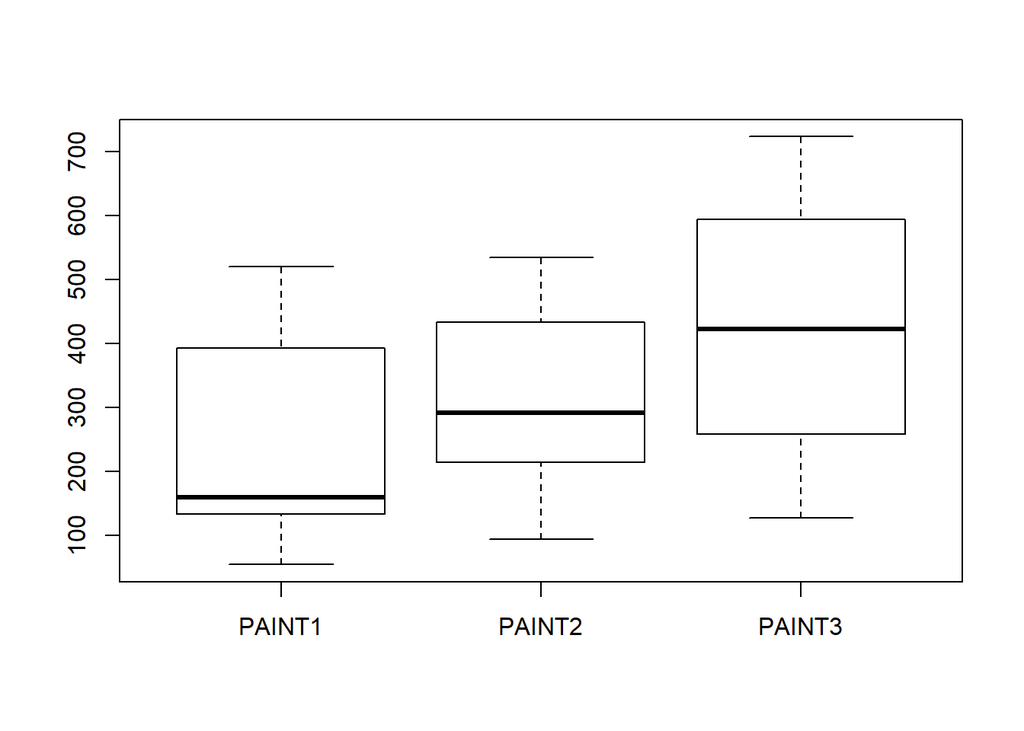

```r
boxplot(paint)
```

Now we will organize it

```r
HOURS = c(paint$PAINT1,paint$PAINT2,paint$PAINT3)
PAINT_=factor(rep(c("PAINT1", "PAINT2", "PAINT3"), c(10,10,10)),levels=(c("PAINT3","PAINT1", "PAINT2")))
df = data.frame(HOURS = HOURS, PAINT_=PAINT_)
head(df)
```

```
##   HOURS PAINT_
## 1   148 PAINT1
## 2    76 PAINT1
## 3   393 PAINT1
## 4   520 PAINT1
## 5   236 PAINT1
## 6   134 PAINT1
```

# Analysis

```r
crdpaint = lm(HOURS~PAINT_,data=df)
summary(crdpaint)
```

```
##
## Call:
## lm(formula = HOURS ~ PAINT_, data = df)
##
## Residuals:
##     Min      1Q  Median      3Q     Max
## -299.80  -95.83  -37.90  153.32  295.20
##
## Coefficients:
##              Estimate Std. Error t value Pr(>|t|)
## (Intercept)    427.80      53.43   8.007 1.32e-08 ***
## PAINT_PAINT1  -198.20      75.56  -2.623   0.0141 *
## PAINT_PAINT2  -117.90      75.56  -1.560   0.1303
## ---
## Signif. codes:  0 '***' 0.001 '**' 0.01 '*' 0.05 '.' 0.1 ' ' 1
##
## Residual standard error: 168.9 on 27 degrees of freedom
## Multiple R-squared:  0.205,  Adjusted R-squared:  0.1462
## F-statistic: 3.482 on 2 and 27 DF,  p-value: 0.04515
```

# ANOVA table

You MUST know the structure of the ANOVA table:

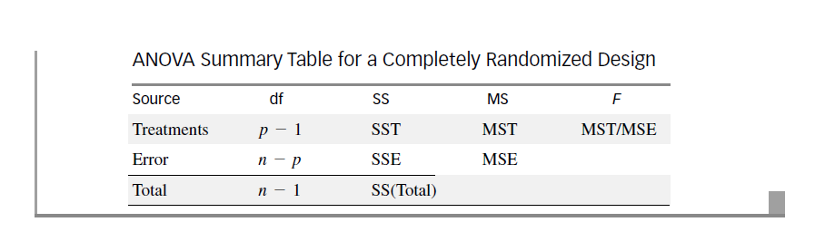

ANOVA table

```r
anova(crdpaint)
```

```
## Analysis of Variance Table
##
## Response: HOURS
##           Df Sum Sq Mean Sq F value  Pr(>F)
## PAINT_     2 198772   99386  3.4819 0.04515 *
## Residuals 27 770671   28543
## ---
## Signif. codes:  0 '***' 0.001 '**' 0.01 '*' 0.05 '.' 0.1 ' ' 1
```

Notice that the p value is significant therefore there is evidence that at least two of the underlying means are different.

The question is which means?

```r
library(s20x)
s20x::multipleComp(crdpaint)
```

```
##                   Estimate   Tukey.L  Tukey.U Tukey.p
## PAINT3  -  PAINT1    198.2   10.8657 385.5343  0.0365
## PAINT3  -  PAINT2    117.9  -69.4343 305.2343  0.2798
## PAINT1  -  PAINT2    -80.3 -267.6343 107.0343  0.5448
```

The results above show that the mean abrasive time for paint 3 is at least 10.9 and at most 385.5 hours more than that of paint 1. There is no strong evidence of a difference for the other paint levels.

The following picture is useful for understanding where the differences are.

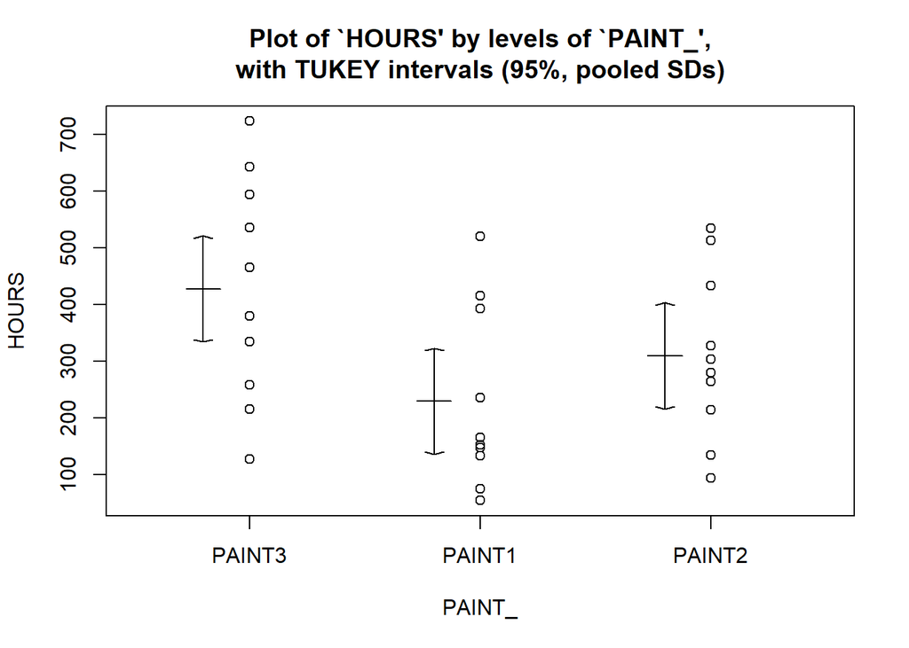

```r
s20x::onewayPlot(crdpaint)
```

# Model matrix

We should be familiar with the design matrix.

```r
model.matrix(crdpaint)
```

```
##    (Intercept) PAINT_PAINT1 PAINT_PAINT2
## 1            1            1            0
## 2            1            1            0
## 3            1            1            0
## 4            1            1            0
## 5            1            1            0
## 6            1            1            0
## 7            1            1            0
## 8            1            1            0
## 9            1            1            0
## 10           1            1            0
## 11           1            0            1
## 12           1            0            1
## 13           1            0            1
## 14           1            0            1
```

[output cut: 21 more lines]

```r
table(df$PAINT)
```

```
##
## PAINT3 PAINT1 PAINT2
##     10     10     10
```

# RBD

Prior to submitting a bid for a construction job, cost engineers prepare a detailed analysis of the estimated labor and materials costs required to complete the job. This estimate will depend on the engineer who performs the analysis. An overly large estimate will reduce the chance of acceptance of a company’s bid price, whereas an estimate that is too low will reduce the profit or even cause the company to lose money on the job. A company that employs three job cost engineers wanted to compare the mean level of the engineers’ estimates. This was done by having each engineer estimate the cost of the same four jobs. The data (in hundreds of thousands of dollars) are shown in Table 14.3.

We will set base levels to Enginer 1 and Job 1.

# Interest

We are primarily interested in whether there is evidence of a difference in the 3 mean levels of the engineer costs.

```r
eng = myread("COSTENG.xls")
head(eng)
```

```
## # A tibble: 6 x 3
##   ENGINEER   JOB  COST
##      <dbl> <dbl> <dbl>
## 1        1     1   4.6
## 2        1     2   6.2
## 3        1     3   5
## 4        1     4   6.6
## 5        2     1   4.9
## 6        2     2   6.3
```

```r
dfeng  = data.frame(ENGINEER = factor(eng$ENGINEER), JOB = factor(eng$JOB), COST = eng$COST )
head(dfeng)
```

```
##   ENGINEER JOB COST
## 1        1   1  4.6
## 2        1   2  6.2
## 3        1   3  5.0
## 4        1   4  6.6
## 5        2   1  4.9
## 6        2   2  6.3
```

```r
ylmf = lm(COST ~ ENGINEER + JOB, data = dfeng)
ylmr = lm(COST ~ JOB, data = dfeng)
# Test Mean Engineer costs
anova(ylmr,ylmf)
```

```
## Analysis of Variance Table
##
## Model 1: COST ~ JOB
## Model 2: COST ~ ENGINEER + JOB
##   Res.Df     RSS Df Sum of Sq      F  Pr(>F)
## 1      8 0.44667
## 2      6 0.18667  2      0.26 4.1786 0.07299 .
## ---
## Signif. codes:  0 '***' 0.001 '**' 0.01 '*' 0.05 '.' 0.1 ' ' 1
```

Since the P value is 0.07 we will not reject the NULL hypothesis at the $\alpha=0.05$ level. Hence it is plausible that the underlying mean costs for the three engineers are the same.

```r
ylmr2 = lm(COST ~ ENGINEER, data = dfeng)
anova(ylmr2,ylmf)
```

```
## Analysis of Variance Table
##
## Model 1: COST ~ ENGINEER
## Model 2: COST ~ ENGINEER + JOB
##   Res.Df    RSS Df Sum of Sq      F    Pr(>F)
## 1      9 6.9500
## 2      6 0.1867  3    6.7633 72.464 4.195e-05 ***
## ---
## Signif. codes:  0 '***' 0.001 '**' 0.01 '*' 0.05 '.' 0.1 ' ' 1
```

As can be seen the partial F stat is large enough to give a practical P value of 0. This means that the blocking instituted as part of the experimental design was likely effective.

# Design matrix

With the variables in standard form within the data frame R will create the following design matrix.

```r
model.matrix(ylmf)
```

```
##    (Intercept) ENGINEER2 ENGINEER3 JOB2 JOB3 JOB4
## 1            1         0         0    0    0    0
## 2            1         0         0    1    0    0
## 3            1         0         0    0    1    0
## 4            1         0         0    0    0    1
## 5            1         1         0    0    0    0
## 6            1         1         0    1    0    0
## 7            1         1         0    0    1    0
## 8            1         1         0    0    0    1
## 9            1         0         1    0    0    0
## 10           1         0         1    1    0    0
## 11           1         0         1    0    1    0
## 12           1         0         1    0    0    1
## attr(,"assign")
## [1] 0 1 1 2 2 2
## attr(,"contrasts")
## attr(,"contrasts")$ENGINEER
## [1] "contr.treatment"
##
## attr(,"contrasts")$JOB
## [1] "contr.treatment"
```

The question is what will happen to the estimates under a different design order (Same experimental design) where the rows of $X$ are re-ordered?

The answer is that we obtain precisely the same estimates, this is not a surprizing result! But will play into our hands if we desire to re-order the matrix to fit the data collection format.

Let $X_r = AX$ where $A$ is orthonormal with one 1 on each row of $A$ so that each column of $A$ contains only one 1. Then $A^{-1}=A^{'}$.

Then, suppose we re-order $X$ that is $AX=X_r$ and $Y$, that is $AY=Y_r$ so that each component of $Y_r$ is associated with its corresponding independent variables $X_r$.

Suppose

$$\hat{\beta}=(X^{'}X)^{-1}X^{'}Y$$

Now we will use the transformed data

$$\hat{\beta}_r=(X_{r}^{'}X_{r})^{-1}X_r^{'}Y_r$$

But:

$$\hat{\beta}_r=((AX)^{'}AX)^{-1}(AX)^{'}Y_r=(X^{'}A^{'}AX)^{-1}X^{'}A^{'}Y_r=(X^{'}X)^{-1}X^{'}Y=\hat{\beta}$$

# Application to a RBD

Suppose we have 3 experimental units and two treatment levels such that we wish to compare the two treatment mean levels.

The design is

$$E(Y) = \beta_0 + \beta_1x_1 + \beta_2x_2 + \beta_3 x_3$$

The first dummy variable is for the treatment level. The other variables are for the presence of block effects.

Suppose we wish to organize data recording so that the response is first from treatment 1 and then last treatment 2. Each response component comes from a measurement on each block.

$$Y=\pmatrix{ y_1 \\y_2 \\ \vdots \\ y_{n}\\y_{n+1}\\ \vdots \\ y_{n + n}}$$

The second set of $y$ components are in order the second measurements.

## What is the design matrix for this data configuration?

We will need to make sure that the independent variables line with the response data.

There are two measurements (treatments) made on each unit (Block). Since we have 3 blocks the first row of $X$ is:

$$X_{1,.} = \pmatrix{1&0&0&0}$$

This row is $y_{1}$ is the a measurement on the first block with treatment level 1. The first 0 is for L1 and the last two 0’s are for the first Block.

$$X_{2,.} = \pmatrix{1&0&1&0}$$

This is for the second block and treatment level 1

We can now complete the design matrix

$$X = \pmatrix{1&0&0&0\\
1&0&1&0\\
1&0&0&1\\
1&1&0&0\\
1&1&1&0\\
1&1&0&1}$$

## Could we have a different ordering?

Yes – if you wished to have a data recording with pairs of resonses together $(y_1,y_4), (y_2, y_5), (y_3, y_6)$ and change a design matrix you could pre-multiply by a suitable re-ordering matrix $A$.

$$A= \pmatrix{1&0&0&0&0&0\\
0&0&0&1&0&0\\
0&1&0&0&0&0\\
0&0&0&0&1&0\\
0&0&1&0&0&0\\
0&0&0&0&0&1\\}_{n\times n}$$

```r
A = matrix(c(1,0,0,0,0,0,
             0,0,0,1,0,0,
             0,1,0,0,0,0,
             0,0,0,0,1,0,
             0,0,1,0,0,0,
             0,0,0,0,0,1),nr=6,nc=6, byrow=TRUE)

A
```

```
##      [,1] [,2] [,3] [,4] [,5] [,6]
## [1,]    1    0    0    0    0    0
## [2,]    0    0    0    1    0    0
## [3,]    0    1    0    0    0    0
## [4,]    0    0    0    0    1    0
## [5,]    0    0    1    0    0    0
## [6,]    0    0    0    0    0    1
```

```r
X=matrix(c(1,0,0,0,
           1,0,1,0,
           1,0,0,1,
           1,1,0,0,
           1,1,1,0,
           1,1,0,1),nr=6,nc=4,byrow=TRUE)

A%*%X
```

```
##      [,1] [,2] [,3] [,4]
## [1,]    1    0    0    0
## [2,]    1    1    0    0
## [3,]    1    0    1    0
## [4,]    1    1    1    0
## [5,]    1    0    0    1
## [6,]    1    1    0    1
```

## Example

3 people undergo 2 exams in a paired design. Each person is a block (3 blocks)

```r
Ex1 = c(40,50,60)
Ex2 = c(50, 60, 74)

Y= c(Ex1,Ex2)
B  = rep(c(1,2,3), 2)
T = rep(c("T1","T2"),c(3,3))
T
```

```
## [1] "T1" "T1" "T1" "T2" "T2" "T2"
```

```r
B=factor(B)

ylm = lm(Y~T + B)
model.matrix(ylm)
```

```
##   (Intercept) TT2 B2 B3
## 1           1   0  0  0
## 2           1   0  1  0
## 3           1   0  0  1
## 4           1   1  0  0
## 5           1   1  1  0
## 6           1   1  0  1
## attr(,"assign")
## [1] 0 1 2 2
## attr(,"contrasts")
## attr(,"contrasts")$T
## [1] "contr.treatment"
##
## attr(,"contrasts")$B
## [1] "contr.treatment"
```

Notice that the design matrix is as we have seen previously.

Lets look at some tests

```r
anova(ylm)
```

```
## Analysis of Variance Table
##
## Response: Y
##           Df Sum Sq Mean Sq F value  Pr(>F)
## T          1 192.67 192.667   72.25 0.01356 *
## B          2 485.33 242.667   91.00 0.01087 *
## Residuals  2   5.33   2.667
## ---
## Signif. codes:  0 '***' 0.001 '**' 0.01 '*' 0.05 '.' 0.1 ' ' 1
```

```r
t.test(Y~T,paired=TRUE)
```

```
##
##  Paired t-test
##
## data:  Y by T
## t = -8.5, df = 2, p-value = 0.01356
## alternative hypothesis: true difference in means is not equal to 0
## 95 percent confidence interval:
##  -17.070204  -5.596463
## sample estimates:
## mean of the differences
##               -11.33333
```

Notice that the p value (0.0135) for the partial F statistic. This has been calculated by removing T from the full model off and hence the NULL hypothesis is $H_0: \mu_2-\mu_1 = 0$

This means we have evidence that the treatment means are different. Notice also the P value for the t.test for paired data. They are the same and $T_{calc}^2 = 72.25 = F_{calc}$